# 5-ый этап индивидуального проекта

Основы информационной безопасности

Верниковская Е. А., НПИбд-01-23

Российский университет дружбы народов, Москва, Россия

17 мая 2025

# Вводная часть

## Цель работы

Научиться пользоваться Burp Suite.

## Задание

1. Научиться пользоваться Burp Suite. Burp Suite представляет собой набор мощных инструментов безопасности веб-приложений, которые демонстрируют реальные возможности злоумышленника, проникающего в веб-приложения

# Выполнение 5-ого этапа индивидуального проекта

## Выполнение основных действий

Запустим mysql и apache2: *sudo systemctl start mysql* и *sudo systemctl start apache2* (рис. 1)

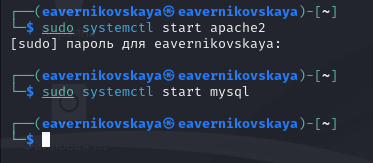

Запуск mysql и apache2

## Выполнение основных действий

Далее запустим Burp Suite (рис. 2)

[figure not shown]

Запуск Burp Suite

## Выполнение основных действий

Откроем сетевые настройки браузера (рис. 3)

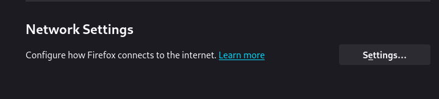

Сетевые настройки браузера

## Выполнение основных действий

Далее изменим настройки сервера для работы с proxy и захватом данных с помощью Burp Suite (рис. 4)

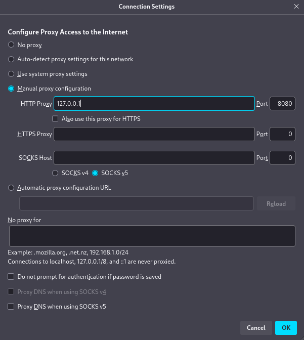

Настройки сервера

## Выполнение основных действий

Изменим настройки proxy инструмента Burp Suite (рис. 5)

[figure not shown]

Настройки Burp Suite

## Выполнение основных действий

Во вкладке Proxy установим “Interxept is on” (рис. 6)

[figure not shown]

Настройки Proxy

## Выполнение основных действий

Для того чтобы Burp Suite работал исправно с локальным сервером установим параметр network_allow_hijacking_localhost на true (рис. 7)

[figure not shown]

Настройки параметров

## Выполнение основных действий

Далее попытаемся зайти в браузере на сайт DVWA. Во вкладке Proxy появится захваченный запрос. Нажмём Forward чтобы загрузить страницу (рис. 8)

[figure not shown]

Получаемые запросы сервера

## Выполнение основных действий

После этго загрузится страница авторизации. Текст запроса поменяется (рис. 9)

[figure not shown]

Страница авторизации

## Выполнение основных действий

История запросов хранится во вкладке Target (рис. 10)

[figure not shown]

История запросов

## Выполнение основных действий

Введём неправильные данные в веб-приложение и нажмём на Login. В запросе мы увидим строчку, в которой отображаются введённые нами данные (в поле для ввода) (рис. 11)

[figure not shown]

Ввод случайных данных

## Выполнение основных действий

Этот запос можно найти во вкладке Target. Нажмём правой кнопкой мыши на хост нужного запроса и нажмём Send to Intruder (рис. 12)

[figure not shown]

POST-запрос с вводом пароля и логина

## Выполнение основных действий

Далее переходим на вкладку Intruder. Мы увидим значения по умолчанию у типа атаки и наш введённый запрос (рис. 13)

[figure not shown]

Вкладка Intruder

## Выполнение основных действий

Изменим значение типа атаки на Cluster bomb attack и проставим специальные символы у техданных, которые мы будем пробивать (то есть у имени пользователяи пароля) (рис. 14)

[figure not shown]

Изменение типа атаки + специальные символы

## Выполнение основных действий

Так как было отмечено 2 параметра для подбора, то нам нужно 2 списка со значениями для подбора. Далее заполняем 2 списка в Payload settings. В строке request count мы будем видеть нужное количество запросов, чтобы проверить все возможные пары пользователь-пароль (рис. 15), (рис. 16)

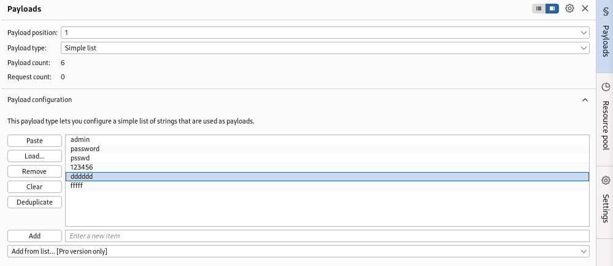

1ый Simple list

## Выполнение основных действий

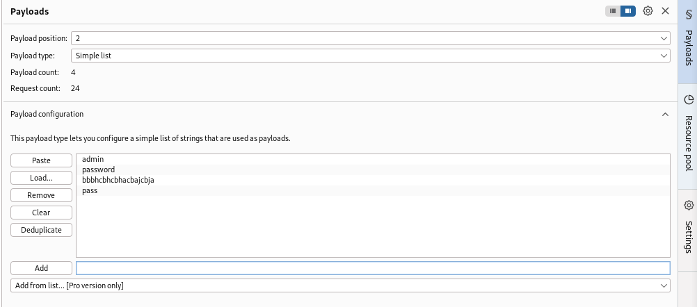

2ой Simple list

## Выполнение основных действий

Далее запустим атаку (рис. 17)

[figure not shown]

Запуск атаки

## Выполнение основных действий

[figure not shown]

Результат запроса (1)

## Выполнение основных действий

Далее проверим результат пары sdmin-password. В этом случае нас перенаправляют на страницу index.php. Это значит что пара верная (рис. 19)

[figure not shown]

Результат запроса (2)

## Выполнение основных действий

Также есть дополнительная проверка. Для этого нужно нажать на Send to Repeater (рис. 20)

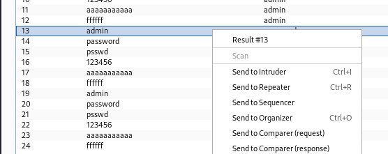

Дополнительная проверка результата

## Выполнение основных действий

Переходим во вкладку Repeater (рис. 21)

[figure not shown]

Вкладка Repeater

## Выполнение основных действий

Нажмём на send. И получим в Response перенаправление на index.php (рис. 22)

[figure not shown]

Окно Response

## Выполнение основных действий

Далее нажмём Follow redirection. После этого мы получим html код в окне Response (подокно Pretty) (рис. 23)

[figure not shown]

html в окне Response

## Выполнение основных действий

Далее в подокне Render получим то как выглядит полученная страница (рис. 24)

[figure not shown]

Полученная страница

# Подведение итогов

## Выводы

В ходе выполнения 5-ого этапа индивидуального проекта мы научились использовать инструмент Burp Suite

## Список литературы

1. Этапы реализации проекта [Электронный ресурс] URL: https://esystem.rudn.ru/mod/page/view.php?id=1220336